# lab_3_Melnik

Лабораторна робота №3

Тема. Аналіз складності алгоритмів. Алгоритми сортування

Мета: засвоїти аналіз складності алгоритмів як технологію на прикладі алгоритмів сортування методами включення та обміну.

Хід роботи

1.Виконати теоретичні розрахунки асимптотичної складності алгоритмів сортування методами вставляння та бульбашки.

Сортування вставками

Найкращий випадок: масив вже відсортований → кожен елемент порівнюється 1 раз → O(n)

Найгірший випадок: масив відсортований у зворотному порядку → кожен елемент проходить всі попередні → O(n²)

Середній випадок → O(n²)

Сортування бульбашкою

Найкращий випадок: відсортований масив якщо є оптимізація → O(n)

Найгірший випадок: зворотний порядок → O(n²)

Середній випадок → O(n²)

2.Реалізувати на Python алгоритм сортування методом бульбашки.

```python
def bubble_sort(arr):
    a = arr.copy()
    n = len(a)

    for i in range(n):
        swapped = False

        for j in range(0, n - i - 1):
            if a[j] > a[j + 1]:
                a[j], a[j + 1] = a[j + 1], a[j]
                swapped = True

        if not swapped:
            break

    return a
```

3.Дослідження реального часу виконання обох алгоритмів на Python

```python
import time
import random

def insertion_sort(arr):
    n = len(arr)
    for i in range(1, n):
        key = arr[i]
        j = i - 1
        while j >= 0 and key < arr[j]:
            arr[j + 1] = arr[j]
            j -= 1
        arr[j + 1] = key
    return arr

def bubble_sort(arr):
    n = len(arr)
    for i in range(n):
        swapped = False
        for j in range(0, n - i - 1):
            if arr[j] > arr[j + 1]:
                arr[j], arr[j + 1] = arr[j + 1], arr[j]
                swapped = True
        if not swapped:
            break
    return arr
n_values = [5, 10, 50, 100, 500, 1000, 2000, 3000, 4000, 5000, 10000, 20000, 50000, 100000]

time_insertion = []
time_bubble = []

num_trials = 3

print("Початок вимірювання часу виконання...")

for n in n_values:
    total_time_insert = 0
    for _ in range(num_trials):
        arr = [random.randint(0, 100000) for _ in range(n)]

        start_time = time.time()
        insertion_sort(arr.copy())
        end_time = time.time()
        total_time_insert += (end_time - start_time)

    time_insertion.append(total_time_insert / num_trials)

    total_time_bubble = 0
    for _ in range(num_trials):
        arr = [random.randint(0, 100000) for _ in range(n)]

        start_time = time.time()
        bubble_sort(arr.copy())
        end_time = time.time()
        total_time_bubble += (end_time - start_time)

    time_bubble.append(total_time_bubble / num_trials)

    print(f"Обробка n={n} завершена. Час Insertion: {time_insertion[-1]:.4f} с, Час Bubble: {time_bubble[-1]:.4f} с")

print("Вимірювання завершено.")
```

[output not shown]

4.Побудова графіку

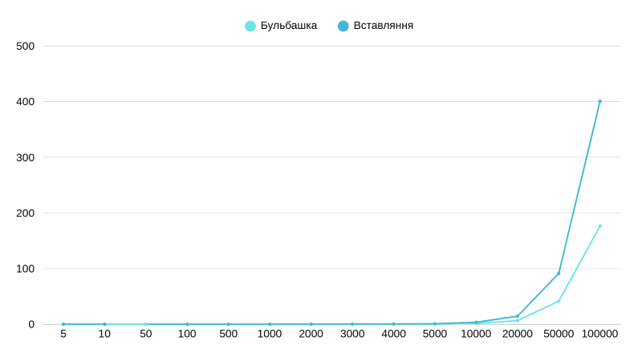

Контрольні питання:

1.Що таке O-нотація і чим вона відрізняється від Ω -нотації?

O-нотація та Ω-нотація - це способи описати швидкість роботи алгоритму, O-нотація показує, наскільки довго може працювати алгоритм у найгіршому випадку, це максимальна оцінка часу. Ω -нотація показує, наскільки швидко принаймні буде працювати алгоритм, це мінімальна оцінка часу.

2.Яку часову складність має алгоритм сортування методом вставляння за найсприятливіших умов, коли масив відсортовано? Відповідь обґрунтувати.

У найсприятливіших умовах алгоритм вставляння має часову скаладність O(n). У сортуванні вставками кожен елемент порівнюється з попередніми, поки не знайде правильне місце. У загальному випадку - це може бути багато порівнянь і зсувів. Але у вже відсортованому масиві на кожній ітерації елемент key порівнюється лише один раз, умова key < a[j] одразу дає False, тому внутрішній цикл не виконується, зсувів немає. Отже, для кожного з n елементів виконується лише одна операція порівняння, без переміщень.

3.Надати визначення ефективного алгоритму.

Ефективний алгоритм — це алгоритм, який мінімізує використання обчислювальних ресурсів, таких як час виконання та пам'ять. Він визначається не тільки за правильністю, але й за швидкістю роботи та економним споживанням ресурсів, що робить його практичним для вирішення певного завдання, особливо при обробці великих обсягів даних.

4.Пояснити поняття головного параметра (розміру) завдання.

Головний параметр (розмір) завдання — це величина, яка характеризує масштаб задачі та визначає, скільки роботи потрібно виконати алгоритму.

5.Функція часової складності має вигляд: F(N) = N^3 + 7N^2 − 14N. Як записати асимптотичну складність у O-нотації?

F(N)=O(N^3)